#### 1. Supervised Machine Learning:

A dataset $A$ with $m$ instances $\textbf{x}_{1}, \textbf{x}_{2}, ..., \textbf{x}_{m}$, where each instance $\textbf{x}_{i}$ is defined by an $n$ features as $\textbf {x}_{i}=(x_{i1}, x_{i2}, ..., x_{in})$. \

Learn a function **${h(x)}$** that maps an instance $x_i \in A$ to a class$y_j\in Y$.

$$\left(\begin{array}{cc}
x_{11} & x_{12} & \dots & x_{1p} \\
x_{21} & x_{22} & \dots & x_{2p} \\
\vdots & \vdots & \ddots & \vdots\\
x_{m1} & \vdots & \dots & x_{mp} \\
\end{array}\right)
\left(\begin{array}{cc}
y_{1}\\
..\\
..\\
..\\
y_{n}
\end{array}\right)$$

One way to improve the learning processs is by applying class-decomposition to the dataset before applying Machine Leanring. Class decomposition describes the process of segmenting each class into a number of homogeneous subclasses. This is achieved through clustering. Utilising class decomposition can provide a number of benefits to supervised learning, especially ensembles. It can be a computationally efficient way to provide a **linearly separable data set** without the need for feature engineering required by techniques like support vector machines and deep learning. Medical data for patient diagnosis may greatly benefit from this technique, as the same disease can have a diverse of symptoms.

#### Class Decomposition

With class decomposition (CD), we can tranform the above dataset into the following form:

$$\left(\begin{array}{cc}
x_{11} & x_{12} & \dots & x_{1p} \\
x_{21} & x_{22} & \dots & x_{2p} \\
\vdots & \vdots & \ddots & \vdots\\
x_{m1} & \vdots & \dots & x_{mp} \\
\end{array}\right)
\left(\begin{array}{cc}
y_{1_{c1}}\\
y_{1_{c2}}\\
..\\
..\\
y_{n_{ck}}
\end{array}\right)$$

\begin{equation}\label{eq4} h_{c}=\begin{bmatrix} & a_1& a_2 & b_1 &b_2 & b_3\\ a_1& \textbf{10}& \textbf{5} & 0 &0 & 0\\ a_2& \textbf{4}& \textbf{31} & 0 &0& 0\\ b_1& 0& 0 & \textbf{8} &\textbf{6}& \textbf{10}\\ b_2& 0& 0 & \textbf{9} &\textbf{1}& \textbf{16}\\ b_3& 0& 0 & \textbf{2} &\textbf{17} &\textbf{7} \end{bmatrix} \end{equation}

Notice that, the confusion matrix shown above is often used to compute the accuracy of a classifier by summing all elements at the diagonal and dividing it by the total number of observations (i.e. $\frac{\sum_{i=1}^{n} h_{ii}}{M}$). However, the accuracy of $h_{c}$ denoted by $Accuracy(h_c)$is computed in a slightly different way to account for the decomposition of the classes in the data set:

\begin{equation}\label{eq5} Accuracy(h) = \frac{\sum_{i=0}^{nClasses}\sum_{j=0}^{k_i}h_c(i,j+ [k_{i-1}*i])}{m} \end{equation}

#### Implementation

Below is a set of functions for implementing CD and apply it along with a Random Forest classifier to show its impact on RF performance. First, the function **clustSet** does the followings:

- Prepare dataset by clustering
- The function will take a dataframe (df), number of clusters(k)
- and an index (ClassIndex) for the label and would return
- a dataframe of the clustered labels

```r
clustSet <- function (df, k=3,ClassIndex) {

    # use split function to split the dataset according to the class label
    # a set of dataframes each representing a class lable will be stored
    # in dfs list()
    require(plyr)
    dfs <- split (df, df[,ClassIndex])
    #cat("splitted ", length(dfs),"\n")
    clustList <- list()
    n <- length(dfs)
    for (i in 1:n){
        # Cluster according to all features excluding the label
        clustList[[i]] <- kmeans(dfs[[i]][,-ClassIndex],k)
        # assign the cluster values to the training set

        #dfs[[i]]$cluster <- paste0("c",clustList[[i]]$cluster,"_",
        #                           (dfs[[i]][,ClassIndex]))

        dfs[[i]]$cluster <- paste0((dfs[[i]][,ClassIndex]),
                                   "_","c",clustList[[i]]$cluster)

    }
    # put all list elements in a dataframe and return it
    allClusteredElements <- ldply (dfs, data.frame)
    # drop the first column 'id' resulting from ldply
    allClusteredElements <- allClusteredElements[,-1]

    allClusteredElements <- allClusteredElements[,-ClassIndex]

    return(allClusteredElements)
}
```

#### How it Works

Here is a set of functions that can be applied along the **clustSet** Function for Machine Learning.

Several datasets needs to be normalized before applying some techniques (e.g. kmeans) which depends on distance calculations and sensetive to noise.

```r
# Normalize data
normalizeData <- function (x ) {

    return ( (x-min(x) ) / ( max(x)- min(x) ))
}
```

Another generic function to fit Random Forest:

```r
fitRFU <- function (nTreeStart = 100, nTreeEnd=1000, nTreeBy=100,
                   trainSet=subTrain, testSet=subTest, lIndex=1, clustC=FALSE){

    set.seed(1111)
    # try different ntree values
    nTrees <- seq(nTreeStart,nTreeEnd, by =nTreeBy)
    nts <- length(nTrees)
    oobErr <- c(nts);
    testErr <- c(nts);
    oobErr1 <- c(nts); # check different ways for computing error
    testErr1 <- c(nts);
    predDF <- data.frame(0,0)
    predDFNC <- data.frame(0,0)
    for (i in 1:nts){


        labels <- as.factor(trainSet[,lIndex])
        train <- trainSet[,-lIndex]

        clustRF <- randomForest(train, labels, xtest=testSet[,-lIndex],
                                    ytest=factor(testSet[,lIndex]),
                                ntree=nTrees[i],
                                    proximity=TRUE, importance = TRUE,
                                    keep.forest=TRUE)


        oobErr[i] <- clustRF$err.rate[nTrees[i]]

        predictions <- levels(labels)[clustRF$test$predicted]

        if (clustC!=TRUE){

            testErr1[i] <- (sum(predictions ==testSet[,lIndex])/nrow(testSet))*100
            predDFNC <- data.frame(predictions, testSet[,lIndex])
            # the above testErr will only apply to nonclustered approach
        }

        else {

            predDF <- data.frame(predictions, testSet[,lIndex])
            predDF$label <- factor(predDF[,2])

            predDF <- predDF[,-2]
            predDF$correctClass <- ifelse(substr(predDF$predictions,1,
                          nchar(as.character(predDF$predictions))-3)==
                          substr(predDF$label,1,
                                 nchar(as.character(predDF$label))-3),1,0)

            testErr1[i] <- (sum(predDF$correctClass==1)/ nrow(testSet))*100

        }
    }
    # copy error values into a data frame and return it
    errDF <- cbind(testErr1,c(1:nts))
    # return data frame of errors
    list(errDF,clustRF,predDF,predDFNC)
}
```

Utility function to show the results (compare ML with CD and without CD), the function takes: * A df (data frame), setSize(training size), iterations(n iterations), * k (n clusters), kInc (increment k by), treeSeq (a vector contains * the starting number of trees, stop number and increment by)

```r
visResults <- function (df, setSize,testSet, incSize, iterations,k,
                        kInc,treeSeq,mfrowS){

    nplots <- round (iterations/2,0)
    treeParams <- seq(treeSeq[1],treeSeq[2],treeSeq[3])
    par(mfrow=mfrowS)
    cIndex <- 3

    for (i in 1:iterations){
        xlabel <- paste0("Number of Trees (K=",k, ", Training Size=", setSize ,
                         ", Testing Size=",testSet,") ")
        matplot(1:length(treeParams), cbind(df[,cIndex],df[,2]),
                pch=c(19,23), col=c('blue','red'),
            xaxt='n', type=c('b','b'),lty=1, ylab="Classification Accuracy %",
            xlab= xlabel, frame=FALSE)
        axis(1, at = 1:length(treeParams), labels = treeParams, cex.axis = 0.7)
        legend("topright", legend=c("RFC","RF"), pch=c(19,23), col=c('blue','red')
          ,bty="n" ,yjust=2,pt.cex=1)
        # Each iteration the sample size is increase by 50
        k <- k + kInc; setSize <- setSize + incSize;
        cIndex <- cIndex + 1
    }
}
```

Now, we want to partition to the datset into training, and testing subsets. The function takes a dataframe (e.g. the dataset), class label index, the the propotion of partitioning as input paramters and return a list contains two dataframes (traning and testing) respectively.

```r
divideTT <- function (df, labelIndex=1,pVal=0.75) {

    require(caret)
    #set.seed(3456)
    trainIndex <- createDataPartition(df[,labelIndex], p = pVal,
                                          list = FALSE,
                                          times = 1)
    training <- df[ trainIndex,]
    testing  <- df[-trainIndex,]

    # for global assignment uncomment
#     assign("train", training, envir = .GlobalEnv)
#     assign("test", testing, envir = .GlobalEnv)
    listSet <- list(training,testing)
    return (listSet)
}
```

```r
fitCRFModel <- function (pValue, dfWN=NULL, trainDF=NULL,testDF=NULL,iterations,
                       kVal=3, incK=2,nTreeStart = 100, nTreeEnd=1000,
                       nTreeBy=100,lIndex=1){

    minErr <- 10000 #Keep best RF
    bestRF <- NULL
    bestK <- kVal

    predDF <- data.frame(0,0)
    if (!is.null(dfWN)){

        listR <- divideTT(dfWN, lIndex, pValue)
        nrow(listR[[1]]); nrow(listR[[2]]);
        table(listR[[1]][lIndex]); table(listR[[2]][lIndex])
        # assign the list of elements to training, testing sets
        trainDF <- listR[[1]]; testDF <- listR[[2]]
    }


    require(randomForest); require(RColorBrewer);
    # This to be put in a for loop
    k <- kVal ; # number of clusters
    # dataframe to hold results
    results <- data.frame("no"= length(seq(nTreeStart, nTreeEnd,nTreeBy)))
    cIndex <- 2 #column index
    for (i in 1:iterations) {

        # cluster the trainingset
        trainC <- clustSet(trainDF, k, lIndex)

        testC <- clustSet(testDF,k,lIndex)

        if (i==1){
            df <- fitRFU(nTreeStart, nTreeEnd, nTreeBy, trainDF, testDF,lIndex,FALSE)
            cName <- paste0("RF","_Inst",nrow(trainDF))
            results <- cbind(results, "x"=df[[1]][,1])
            names(results)[cIndex] <- cName
            cIndex <- cIndex + 1
        }
        cdf<- fitRFU(nTreeStart, nTreeEnd, nTreeBy, trainC, testC,ncol(trainC),TRUE)

        cName <- paste0("K",k,"_Inst")
        results <- cbind(results, "x"=cdf[[1]][,1])
        #write.csv(trainC,"trainC.cs")
        errVal <-  100 - min(cdf[[1]][,1])
        if (errVal < minErr) {
            bestRF <- cdf[[2]]

            predDF <- cdf[[3]]
            bestK <- k

        }
        names(results)[cIndex] <- cName
        cIndex <- cIndex + 1
        # update results

        k <- k+incK

    }
#           1           2           3           4       5   6
    list(results, nrow(trainDF),nrow(testDF), bestRF,bestK,predDF)
}
```

#### Example (Diabetes Dataset)

**Load** the dataset

```r
diabetes <- read.table("data/diabetes_pima_indians.txt",
                       sep=',',head=FALSE,na="?")
cat("Number of Rows in the Dataset is: ", nrow(diabetes),"\n")
```

```
## Number of Rows in the Dataset is:  768
```

```r
cat("Number of Columns: ", ncol(diabetes),"\n")
```

```
## Number of Columns:  9
```

```r
names(diabetes)[9] <- "label" #label either test postive or negative
table(diabetes$label)
```

```
##
##   0   1
## 500 268
```

**Missing values**:

```r
x <- sapply(diabetes, function(x) sum(is.na(x)))
cat ("Total Number of Missing Values: ", sum(x),"\n")
```

```
## Total Number of Missing Values:  0
```

**Normalise the Data**

```r
diabetesN <- as.data.frame(lapply(diabetes[,-9], normalizeData) )
diabetesN$label <-  diabetes$label
```

**Set values** and run the Experiment:

```r
# split ratio
pValue <- 0.66  ; iterations <- 6;
mfrow <-c(3,2);
# start with k = 2
kVal <- 2 ; incK <- 1 ;nTreeStart <- 100 ;
nTreeEnd <- 1000 ; nTreeBy <- 100;
lIndex = 9

listR <- divideTT(diabetesN, lIndex, pValue)
        # assign the list of elements to training, testing sets
        trainDF <- listR[[1]]; testDF <- listR[[2]]


results <- fitCRFModel (pValue,NULL, trainDF, testDF, iterations, kVal,
                       incK,nTreeStart, nTreeEnd,nTreeBy,lIndex)
```

Extact and save results for visualisations and comparisons:

```r
dataset <- "Diabetes"
nrowTrain <- results[[2]]; nrowTest <- results[[3]];
nCols<- ncol(diabetesN); nClass <-2; bestK<- results[[5]]
cRF<-round(max(results[[1]][,3:ncol(results[[1]])]),2)
RF <- round(max(results[[1]][,2]),2)
winLose<- ifelse( cRF >RF,"Win",ifelse(cRF==RF,"Tie","Lose"))
```

Show results of RF performance with/without CD:

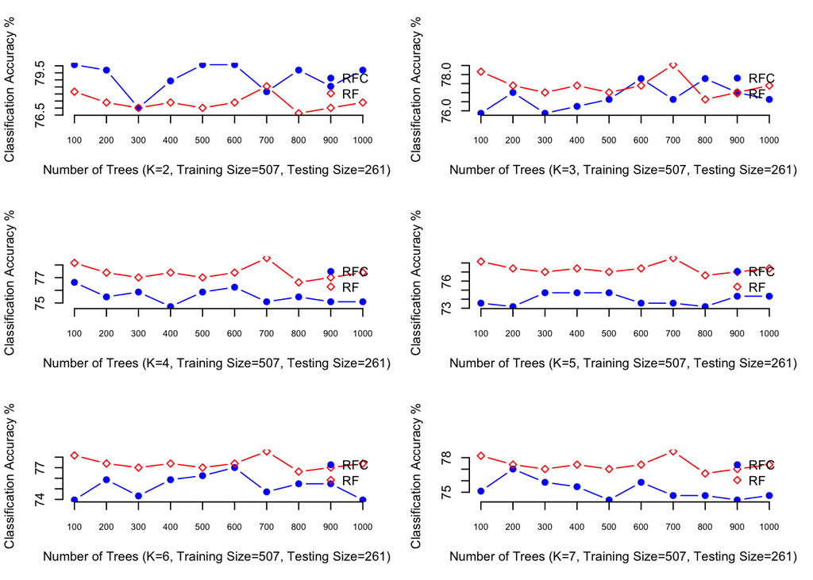

```r
treeParams <- c(100,1000,100)
visResults(results[[1]], results[[2]],results[[3]],0, iterations,kVal,
               incK,treeParams,mfrow)
```

#### Results and To-Do List

- The data was split into train / testing sets, but this could lead to a risk of over fitting, so you need to split the data into train, validate and test set, and hold out the testing set for the final stage and use it only when evaluating the best RFC model
- The **k** value here wasn’t optimised, but was found experimentally. Think how can the best k value be set to optimise RF performance?
- CD can be applied to handle class-imbalance, for example in a largely imbalanced dataset, the majority class instances can be decomposed into subclasses to reduce its dominance over the learning space. This also ensures that no information loss will be caused as it is often the case when applying undersampling. Below is a slightly modified function, that can apply decomposition to a particular class. The function does similar job as the above one:
- Subset your dataset according to class-labels. Suppose you are working with IRIS dataset which has three class labels. Then you will have three subsets of data (one for each class label)
- Cluster each subset (i.e. into 2 clusters, or perhaps you want to try other values)
- Merge all clusters subsets into single data frame

```r
clustData <- function (df,ClassIndex,kmeansClasses = rep(0,unique(df[,ClassIndex]))) {
    # use split function to split the dataset according to the class label
    # a set of dataframes each representing a class label will be stored
    # in dfs list()
    dfs <- split (df, df[,ClassIndex])
    # create empty list
    clustList <- list()
    n <- length(dfs)
    for (i in 1:length(kmeansClasses)){
        # Cluster according to all features excluding the label
        if (kmeansClasses[i]>1 & kmeansClasses[i]< nrow(dfs[[i]])){

            clustList[[i]] <- kmeans(dfs[[i]][,-ClassIndex],kmeansClasses[i])
            #plotcluster(clustList[[i]], clustList[[i]]$cluster)
            dfs[[i]]$cluster <- paste0((dfs[[i]][,ClassIndex]),
                                       "_","c",clustList[[i]]$cluster)
        }
        else {

            dfs[[i]]$cluster = paste0((dfs[[i]][,ClassIndex]),
                                      "_c0")
        }
    }
    # put all list elements in a dataframe and return it
    # note that ldply() require the library plyr
    allClusteredElements <- ldply (dfs, data.frame)
    # drop the first column 'id' resulting from ldply
    allClusteredElements <- allClusteredElements[,-1]

    allClusteredElements <- allClusteredElements[,-ClassIndex]
    return(allClusteredElements)
}
```

**Now** Suppose your dataset is IRIS, you decided to cluster each class into 2 subclasses, then this is how you can do it using the above function:

```r
# create backup copy of the dataset
library(plyr)
df <- iris
# notice that ncol(df) was used here because it is the index of the class label
dfU <- clustData(df,ncol(df),rep(2,length(unique(df[,ncol(df)]))))
#
```

```r
head(df)
```

```
##   Sepal.Length Sepal.Width Petal.Length Petal.Width Species
## 1          5.1         3.5          1.4         0.2  setosa
## 2          4.9         3.0          1.4         0.2  setosa
## 3          4.7         3.2          1.3         0.2  setosa
## 4          4.6         3.1          1.5         0.2  setosa
## 5          5.0         3.6          1.4         0.2  setosa
## 6          5.4         3.9          1.7         0.4  setosa
```

And here is the class distribution in the original dataset:

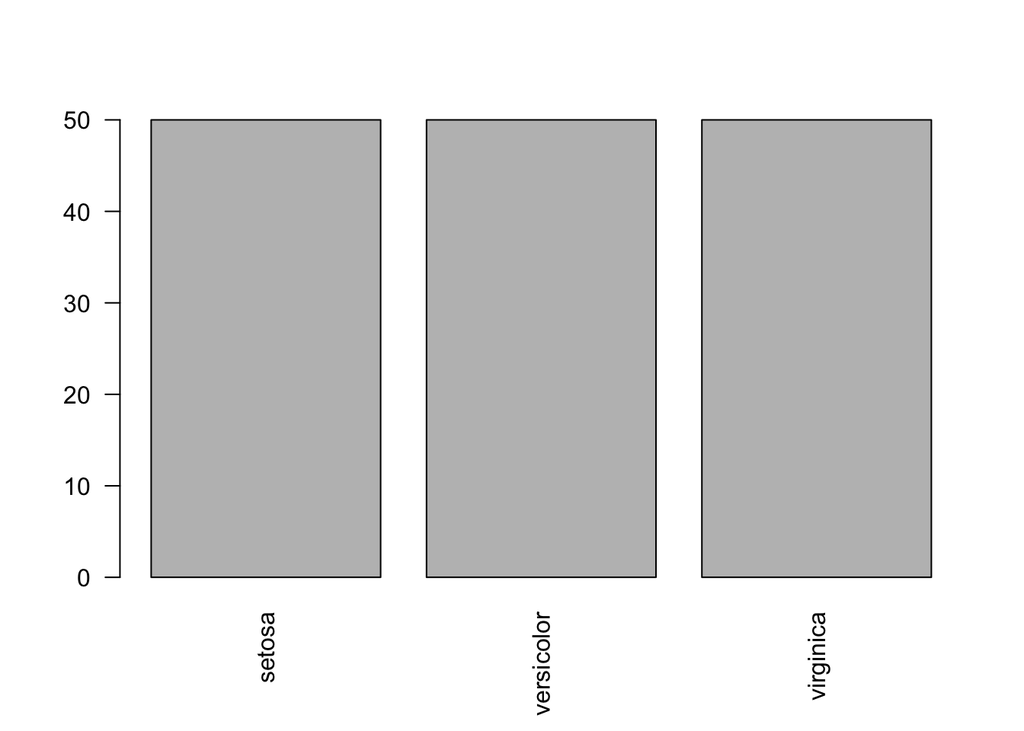

```r
barplot(table(df$Species),las=2)
```

```r
head(dfU)
```

```
##   Sepal.Length Sepal.Width Petal.Length Petal.Width   cluster
## 1          5.1         3.5          1.4         0.2 setosa_c2
## 2          4.9         3.0          1.4         0.2 setosa_c1
## 3          4.7         3.2          1.3         0.2 setosa_c1
## 4          4.6         3.1          1.5         0.2 setosa_c1
## 5          5.0         3.6          1.4         0.2 setosa_c2
## 6          5.4         3.9          1.7         0.4 setosa_c2
```

**Notice** how the class distribution changes in the new dataset

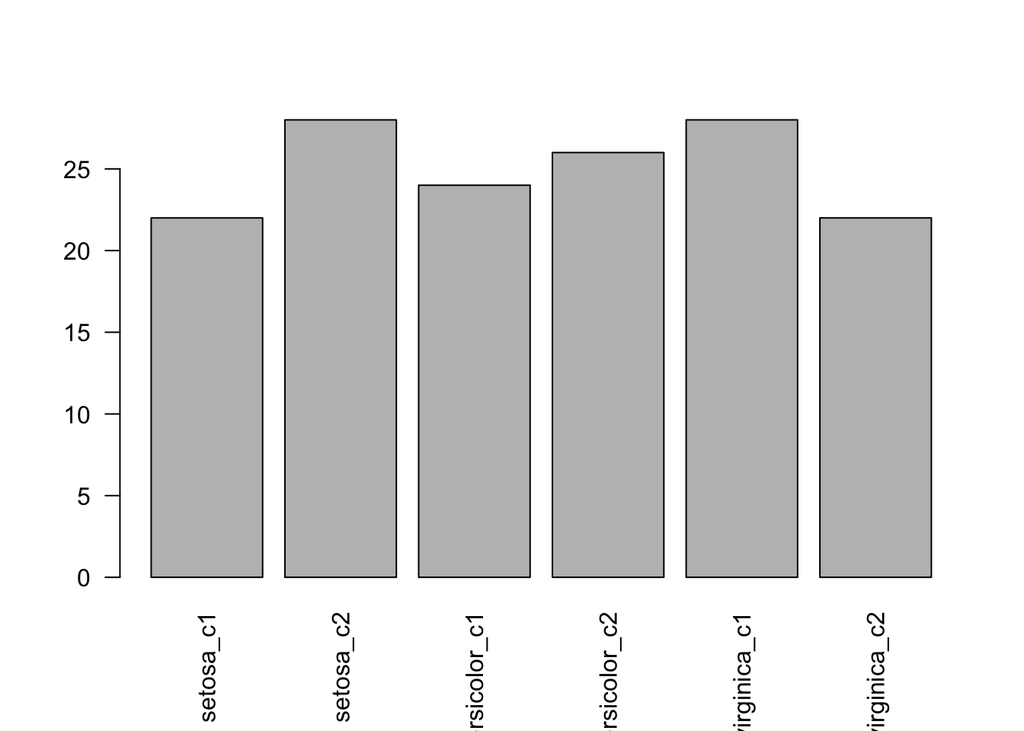

```r
barplot(table(dfU$cluster),las=2)
```